# Grenier_Yohan_1_notebook_072023

**OPTIMISATION DES DONNÉES DU SITE BOTTLENECK**

**SUPPORT DE [PRÉSENTATION](https://preview.shorthand.com/NR7HakNG16WgJVPE)**

### Objectifs :

Solution plus centralisée grâce à un rapprochement entre 2 bases:

un export de l’ERP contenant les références produit, leur prix de vente et leur état de stock

un export d’une table de l’outil de CMS contenant les informations des produits commercialisés en ligne (nom, description, nombre de ventes...)

Demandes spécifiques:

chiffre d’affaires par produit

total du chiffre d’affaires réalisé en ligne

Analyse de la variable **price** afin de détecter d’éventuelles valeurs aberrantes :

les lister

en faire une représentation graphique pour plus de lisibilité

### Import libraries needed

```python
import pandas as pd
import numpy as np
import seaborn as sns
import matplotlib.pyplot as plt
from scipy import stats

import warnings
warnings.simplefilter("ignore")
```

### Fonctions definition

```python
def drop_Tags(cell):
    """
    "<" and ">" are like On/off button
    When there are a ">" without "<" on back so the fonction catch the text after into the next "<"

    """
    new_sentence = []
    i = 0 # < = 1 ; > = 0  like on/off button

    for char in cell:
        if cell[0] != "<":      #If there are no tags -> don't change the sentence
            return cell

        elif char == "<":
            i += 1
        elif i == 0:
            new_sentence.append(char)
        elif char == ">":
            i -= 1
        else: continue

    new_sentence = "".join(new_sentence)
    return new_sentence
```

### Import data needed for analysis

```python
#Data import from Fichier_erp
df_productsinfos = pd.read_excel("DATA_sources/Fichier_erp.xlsx")

#Data import from Fichier_liaison
df_connection = pd.read_excel("DATA_sources/Fichier_liaison.xlsx")

#Data import from Fichier_web
df_webinfos = pd.read_excel("DATA_sources/Fichier_web.xlsx")
```

### Data discover

#### 1. Products info:

```python
#View of Dataframe size
df_productsinfos.shape
```

```
(825, 5)
```

```python
#View of dataframe description
df_productsinfos.info()
```

```
<class 'pandas.core.frame.DataFrame'>
RangeIndex: 825 entries, 0 to 824
Data columns (total 5 columns):
 #   Column          Non-Null Count  Dtype
---  ------          --------------  -----
 0   product_id      825 non-null    int64
 1   onsale_web      825 non-null    int64
 2   price           825 non-null    float64
 3   stock_quantity  825 non-null    int64
 4   stock_status    825 non-null    object
dtypes: float64(1), int64(3), object(1)
memory usage: 32.4+ KB
```

```python
#View dataframe
df_productsinfos
```

|  | product_id | onsale_web | price | stock_quantity | stock_status |
| --- | --- | --- | --- | --- | --- |
| 0 | 3847 | 1 | 24.2 | 0 | outofstock |
| 1 | 3849 | 1 | 34.3 | 0 | outofstock |
| 2 | 3850 | 1 | 20.8 | 0 | outofstock |
| 3 | 4032 | 1 | 14.1 | 0 | outofstock |
| 4 | 4039 | 1 | 46.0 | 0 | outofstock |
| ... | ... | ... | ... | ... | ... |
| 820 | 7203 | 0 | 45.0 | 30 | instock |
| 821 | 7204 | 0 | 45.0 | 9 | instock |
| 822 | 7247 | 1 | 54.8 | 23 | instock |
| 823 | 7329 | 0 | 26.5 | 14 | instock |
| 824 | 7338 | 1 | 16.3 | 45 | instock |

825 rows × 5 columns

```python
#Check duplicates
df_productsinfos.duplicated().sum()
```

```
0
```

```python
#Check unique key
df_productsinfos["product_id"].duplicated().sum()
```

```
0
```

```python
#Check how many different stock status there are (there are not empty values)
df_productsinfos["stock_status"].unique()
```

```
array(['outofstock', 'instock'], dtype=object)
```

```python
#Check min and max on numeric series
df_productsinfos.describe().round(2)
```

|  | product_id | onsale_web | price | stock_quantity |
| --- | --- | --- | --- | --- |
| count | 825.00 | 825.00 | 825.00 | 825.00 |
| mean | 5162.60 | 0.87 | 32.38 | 26.58 |
| std | 902.64 | 0.34 | 26.83 | 45.88 |
| min | 3847.00 | 0.00 | -8.00 | -1.00 |
| 25% | 4348.00 | 1.00 | 14.60 | 1.00 |
| 50% | 4907.00 | 1.00 | 24.40 | 11.00 |
| 75% | 5805.00 | 1.00 | 42.00 | 34.00 |
| max | 7338.00 | 1.00 | 225.00 | 578.00 |

The data are about products informations: id, show on web site (0|1), unity price, stock quantity

Pay attention on:

- negative price
- high price (outlier?) max = 225 | med = 24.40
- negative stock_quantity
- high stock_quantity (outlier?) max = 578 | med = 11

#### 2. Connection :

```python
#View of Dataframe size
df_connection.shape
```

```
(825, 2)
```

```python
#View of dataframe description
df_connection.info()
```

```
<class 'pandas.core.frame.DataFrame'>
RangeIndex: 825 entries, 0 to 824
Data columns (total 2 columns):
 #   Column      Non-Null Count  Dtype
---  ------      --------------  -----
 0   product_id  825 non-null    int64
 1   id_web      734 non-null    object
dtypes: int64(1), object(1)
memory usage: 13.0+ KB
```

Some id_web are NaN and object Dtype (ex: 14680-1)

```python
#Drop NaN ID cause there are useless
df_connection.dropna(inplace=True)
```

```python
#View dataframe
df_connection
```

|  | product_id | id_web |
| --- | --- | --- |
| 0 | 3847 | 15298 |
| 1 | 3849 | 15296 |
| 2 | 3850 | 15300 |
| 3 | 4032 | 19814 |
| 4 | 4039 | 19815 |
| ... | ... | ... |
| 792 | 7023 | 15891 |
| 793 | 7025 | 15887 |
| 822 | 7247 | 13127-1 |
| 823 | 7329 | 14680-1 |
| 824 | 7338 | 16230 |

734 rows × 2 columns

```python
#Check duplicates
df_connection.duplicated().sum()
```

```
0
```

```python
#Check unique key product_id
df_connection["product_id"].duplicated().sum()
```

```
0
```

```python
#Check unique key id_web
df_connection["id_web"].duplicated().sum()
```

```
0
```

Min/max check is useless cause the data are ID

#### 3. Web infos :

```python
df_webinfos.shape
```

```
(1513, 28)
```

```python
df_webinfos.info()
```

```
<class 'pandas.core.frame.DataFrame'>
RangeIndex: 1513 entries, 0 to 1512
Data columns (total 28 columns):
 #   Column                 Non-Null Count  Dtype
---  ------                 --------------  -----
 0   sku                    1428 non-null   object
 1   virtual                1513 non-null   int64
 2   downloadable           1513 non-null   int64
 3   rating_count           1513 non-null   int64
 4   average_rating         1430 non-null   float64
 5   total_sales            1430 non-null   float64
 6   tax_status             716 non-null    object
 7   tax_class              0 non-null      float64
 8   post_author            1430 non-null   float64
 9   post_date              1430 non-null   datetime64[ns]
```

[output cut: 20 more lines]

```python
#Columns 7, 11, 17, 21 have no infos -> drop columns
df_webinfos.drop(columns={"tax_class", "post_content", "post_password", "post_content_filtered"}, inplace=True)
```

```python
#sku is own ID, NaN are useless -> drop rows
df_webinfos.dropna(subset="sku", inplace=True)
```

```python
#Check duplicates
df_webinfos.duplicated().sum()
```

```
0
```

```python
#Check duplicates on sku (ID)
df_webinfos["sku"].duplicated().sum()
```

```
714
```

On 1428 rows, 714 are duplicate. So each sku has a double rows

3 differents points between 2 same sku (ID):

- Some columns with same informations
- tax_status, post_excerpt and post_mime_type have NaN in only one row
- post_type (usefull to pick product) and guid are different

```python
#Create a dataframe with one row correspondant to product category of each duplicated sku
df_missings_values = df_webinfos.loc[df_webinfos["post_type"] != "product"]
```

```python
#With the copy of duplicated rows saved, we can drop them from the original dataframe
df_webinfos.drop(df_webinfos.loc[df_webinfos["post_type"] != "product"].index, inplace=True)
```

```python
df_webinfos.info()
```

```
<class 'pandas.core.frame.DataFrame'>
Index: 714 entries, 2 to 1510
Data columns (total 24 columns):
 #   Column             Non-Null Count  Dtype
---  ------             --------------  -----
 0   sku                714 non-null    object
 1   virtual            714 non-null    int64
 2   downloadable       714 non-null    int64
 3   rating_count       714 non-null    int64
 4   average_rating     714 non-null    float64
 5   total_sales        714 non-null    float64
 6   tax_status         714 non-null    object
 7   post_author        714 non-null    float64
 8   post_date          714 non-null    datetime64[ns]
 9   post_date_gmt      714 non-null    datetime64[ns]
```

[output cut: 16 more lines]

```python
#Catch the informations missing in the first df from the 2nd df
#Change na values with specific sign
"""
df_webinfos.tax_status.fillna("-", inplace=True)
df_webinfos.post_excerpt.fillna("-", inplace=True)
df_webinfos.post_mime_type.fillna("-", inplace=True)


for sku in df_webinfos["sku"]:

    tax_status = df_webinfos.loc[df_webinfos["sku"] == sku, "tax_status"].item()
    tax_status_noNan = df_missings_values.loc[df_missings_values["sku"] == sku, "tax_status"].item()
    if tax_status == "-":
        tax_status = tax_status_noNan


    post_excerpt = df_webinfos.loc[df_webinfos["sku"] == sku, "post_excerpt"].item()
    post_excerpt_noNan = df_missings_values.loc[df_missings_values["sku"] == sku, "post_excerpt"].item()
    if post_excerpt == "-":
        post_excerpt = post_excerpt_noNan


    post_mime_type = df_webinfos.loc[df_webinfos["sku"] == sku, "post_mime_type"].item()
    post_mime_type_noNan = df_missings_values.loc[df_missings_values["sku"] == sku, "post_mime_type"].item()
    if post_mime_type == "-":
        post_mime_type = post_mime_type_noNan"""
```

[output not shown]

```python
df_missings_values.info()
```

```
<class 'pandas.core.frame.DataFrame'>
Index: 714 entries, 0 to 1512
Data columns (total 24 columns):
 #   Column             Non-Null Count  Dtype
---  ------             --------------  -----
 0   sku                714 non-null    object
 1   virtual            714 non-null    int64
 2   downloadable       714 non-null    int64
 3   rating_count       714 non-null    int64
 4   average_rating     714 non-null    float64
 5   total_sales        714 non-null    float64
 6   tax_status         0 non-null      object
 7   post_author        714 non-null    float64
 8   post_date          714 non-null    datetime64[ns]
 9   post_date_gmt      714 non-null    datetime64[ns]
```

[output cut: 16 more lines]

```python
df_webinfos.describe()
```

|  | virtual | downloadable | rating_count | average_rating | total_sales | post_author | post_date | post_date_gmt | post_modified | post_modified_gmt | post_parent | menu_order | comment_count |
| --- | --- | --- | --- | --- | --- | --- | --- | --- | --- | --- | --- | --- | --- |
| count | 714.0 | 714.0 | 714.0 | 714.0 | 714.000000 | 714.000000 | 714 | 714 | 714 | 714 | 714.0 | 714.0 | 714.0 |
| mean | 0.0 | 0.0 | 0.0 | 0.0 | 4.012605 | 1.998599 | 2018-08-22 03:57:52.950980352 | 2018-08-22 02:29:08.581232640 | 2020-06-20 21:45:25.694678016 | 2020-06-20 19:51:53.929971968 | 0.0 | 0.0 | 0.0 |
| min | 0.0 | 0.0 | 0.0 | 0.0 | 0.000000 | 1.000000 | 2018-02-08 12:58:52 | 2018-02-08 11:58:52 | 2018-02-20 15:19:23 | 2018-02-20 14:19:23 | 0.0 | 0.0 | 0.0 |
| 25% | 0.0 | 0.0 | 0.0 | 0.0 | 0.000000 | 2.000000 | 2018-02-27 20:01:12.500000 | 2018-02-27 19:01:12.500000 | 2020-06-18 18:32:35 | 2020-06-18 16:32:35 | 0.0 | 0.0 | 0.0 |
| 50% | 0.0 | 0.0 | 0.0 | 0.0 | 1.000000 | 2.000000 | 2018-04-19 14:52:10 | 2018-04-19 12:52:10 | 2020-08-04 09:30:06.500000 | 2020-08-04 07:30:06.500000 | 0.0 | 0.0 | 0.0 |
| 75% | 0.0 | 0.0 | 0.0 | 0.0 | 4.000000 | 2.000000 | 2019-01-31 14:35:47 | 2019-01-31 13:35:47 | 2020-08-25 10:32:32 | 2020-08-25 08:32:32 | 0.0 | 0.0 | 0.0 |
| max | 0.0 | 0.0 | 0.0 | 0.0 | 96.000000 | 2.000000 | 2020-07-20 11:00:00 | 2020-07-20 09:00:00 | 2020-08-27 18:55:03 | 2020-08-27 16:55:03 | 0.0 | 0.0 | 0.0 |
| std | 0.0 | 0.0 | 0.0 | 0.0 | 8.518183 | 0.037424 | NaN | NaN | NaN | NaN | 0.0 | 0.0 | 0.0 |

```python
#Some columns are == 0 -> drop these columns
df_webinfos.drop(columns={"virtual", "downloadable", "rating_count", "average_rating", "post_parent", "menu_order", "comment_count"}, inplace=True)
```

```python
#View of different status are possible for each colomuns with status or type
for column in df_webinfos.columns:
    if (column.find("status") != -1) or column.find("type") != -1:
        print("\nStatus for", column,":")
        for status in df_webinfos[column].unique():
            print("                        -",status)
```

```
Status for tax_status :
                        - taxable

Status for post_status :
                        - publish

Status for comment_status :
                        - closed

Status for ping_status :
                        - closed

Status for post_type :
                        - product

Status for post_mime_type :
                        - nan
```

```python
#These columns have no relevant information -> send them in archive dataframe then drop columns
df_cols_archives = df_webinfos[["sku","post_status", "comment_status", "ping_status","tax_status", "post_type", "post_mime_type"]]

#Drop columns
df_webinfos.drop(columns={"post_status", "comment_status", "ping_status","tax_status", "post_type", "post_mime_type"}, inplace=True)
```

```python
#Drop ALL tags in every cells of post_excerpt  (ex: <span> <div></div> </span>)
for row in df_webinfos.index:
    cell = df_webinfos["post_excerpt"][row]
    cell = str(cell)

    df_webinfos["post_excerpt"][row] = drop_Tags(cell)
```

```python
#View of dataframe
df_webinfos
```

|  | sku | total_sales | post_author | post_date | post_date_gmt | post_title | post_excerpt | post_name | post_modified | post_modified_gmt | guid |
| --- | --- | --- | --- | --- | --- | --- | --- | --- | --- | --- | --- |
| 2 | 15075 | 3.0 | 2.0 | 2018-02-14 15:39:43 | 2018-02-14 14:39:43 | Parés Baltà Penedès Indigena 2017 | Des couleurs et aromes intenses où le fruit et... | pares-balta-penedes-indigena-2017 | 2020-08-20 15:35:02 | 2020-08-20 13:35:02 | https://www.bottle-neck.fr/?post_type=product&... |
| 3 | 16209 | 6.0 | 2.0 | 2018-02-14 17:15:31 | 2018-02-14 16:15:31 | Maurel Cabardès Tradition 2017 | Un joli nez aux arômes de fruits rouges, de ca... | maurel-cabardes-tradition-2017 | 2020-08-05 18:05:03 | 2020-08-05 16:05:03 | https://www.bottle-neck.fr/?post_type=product&... |
| 5 | 13895 | 0.0 | 2.0 | 2019-03-19 10:41:50 | 2019-03-19 09:41:50 | Château Saransot-Dupré Bordeaux Blanc 2016 | Rareté en Médoc (mais d’A.O.C. Bordeaux) le do... | chateau-saransot-dupre-bordeaux-blanc-2016 | 2020-04-25 21:11:40 | 2020-04-25 19:11:40 | https://www.bottle-neck.fr/?post_type=product&... |
| 6 | 12857 | 0.0 | 2.0 | 2018-04-12 17:56:13 | 2018-04-12 15:56:13 | Château de Meursault Puligny-Montrachet 1er Cr... | Il présente une grande fraîcheur minérale au n... | chateau-de-puligny-montrachet-1cru-champ-canet... | 2020-02-06 16:35:02 | 2020-02-06 15:35:02 | https://www.bottle-neck.fr/?post_type=product&... |
| 9 | 14106 | 0.0 | 2.0 | 2019-06-08 09:54:21 | 2019-06-08 07:54:21 | Stéphane Tissot Château-Chalon 2011 | Ce vin peut-être dégusté sur sa jeunesse mais ... | stephane-tissot-chateau-chalon-2011 | 2020-05-29 17:35:03 | 2020-05-29 15:35:03 | https://www.bottle-neck.fr/?post_type=product&... |
| ... | ... | ... | ... | ... | ... | ... | ... | ... | ... | ... | ... |
| 1501 | 15941 | 4.0 | 2.0 | 2018-02-12 14:26:52 | 2018-02-12 13:26:52 | Domaine de la Jérôme Côtes du Rhône Village 201 | Un vin opulent, à la texture onctueuse, et tou... | jerome-cotes-du-rhone-2018 | 2020-06-25 14:00:03 | 2020-06-25 12:00:03 | https://www.bottle-neck.fr/?post_type=product&... |
| 1503 | 10459 | 0.0 | 2.0 | 2018-04-13 15:58:19 | 2018-04-13 13:58:19 | Alphonse Mellot Sancerre Rouge Génération XIX ... | Robe d'un superbe rubis, dense et profond - As... | alphonse-mellot-sancerre-rouge-generation-xix-... | 2020-08-24 14:05:02 | 2020-08-24 12:05:02 | https://www.bottle-neck.fr/?post_type=product&... |
| 1507 | 16320 | 3.0 | 2.0 | 2018-02-12 12:49:29 | 2018-02-12 11:49:29 | Mourgues du Grès IGP Pont du Gard Terre d'Arge... | Magnifique exemple d’assemblage réussi, ou cha... | mourgues-du-gres-costieres-de-nimes-terre-darg... | 2020-08-25 11:15:03 | 2020-08-25 09:15:03 | https://www.bottle-neck.fr/?post_type=product&... |
| 1509 | 15663 | 3.0 | 2.0 | 2018-02-27 10:27:01 | 2018-02-27 09:27:01 | Chermette Domaine du Vissoux Brouilly Pierreux... | Le Brouilly est le plus méridional des crus du... | chermette-domaine-du-vissoux-brouilly-pierreux... | 2020-08-01 09:35:02 | 2020-08-01 07:35:02 | https://www.bottle-neck.fr/?post_type=product&... |
| 1510 | 15910 | 0.0 | 2.0 | 2019-03-28 10:59:43 | 2019-03-28 09:59:43 | Thevenet Quintaine Viré-Clessé La Bongran 2015 | C’est dans cette cuvée la pleine expression du... | thevenet-quintaine-vire-clesse-la-bongran-2015 | 2020-08-14 10:45:02 | 2020-08-14 08:45:02 | https://www.bottle-neck.fr/?post_type=product&... |

714 rows × 11 columns

### Data exploration

#### Merging PRODUCTS INFOS and WEB INFOS with CONNECTION

```python
#Check if there are all the primary keys needed to join
pk_products_infos = df_productsinfos["product_id"].tolist()
pk_connection_products = df_connection["product_id"].tolist()

pk_products_notin_connection = []
for key in pk_products_infos:
    if key not in pk_connection_products:
        pk_products_notin_connection.append(key)

print("It's missing:", len(pk_products_notin_connection),"key in the connection source")
```

```
It's missing: 91 key in the connection source
```

```python
#Check if there are all the primary keys needed to join
pk_web_infos = df_webinfos["sku"].tolist()
pk_connection_web = df_connection["id_web"].tolist()

pk_web_notin_connection = []
for key in pk_web_infos:
    if key not in pk_connection_web:
        pk_web_notin_connection.append(key)

print("It's missing:", len(pk_web_notin_connection),"key in the connection source")
```

```
It's missing: 0 key in the connection source
```

```python
#Merge Connection ON Products infos
df_temp = pd.merge(df_productsinfos, df_connection, on="product_id" )
```

```python
#Merge products info ON df_temp to create the full dataframe
df_complete = pd.merge(df_temp, df_webinfos, left_on="id_web", right_on="sku")
```

```python
#Check if a key is missing
df_complete["product_id"].isna().sum()
```

```
0
```

```python
#Check if a key is missing
df_complete["id_web"].isna().sum()
```

```
0
```

#### Sales analysis

```python
df_complete.info()
```

```
<class 'pandas.core.frame.DataFrame'>
RangeIndex: 714 entries, 0 to 713
Data columns (total 17 columns):
 #   Column             Non-Null Count  Dtype
---  ------             --------------  -----
 0   product_id         714 non-null    int64
 1   onsale_web         714 non-null    int64
 2   price              714 non-null    float64
 3   stock_quantity     714 non-null    int64
 4   stock_status       714 non-null    object
 5   id_web             714 non-null    object
 6   sku                714 non-null    object
 7   total_sales        714 non-null    float64
 8   post_author        714 non-null    float64
 9   post_date          714 non-null    datetime64[ns]
 10  post_date_gmt      714 non-null    datetime64[ns]
 11  post_title         714 non-null    object
 12  post_excerpt       714 non-null    object
 13  post_name          714 non-null    object
 14  post_modified      714 non-null    datetime64[ns]
 15  post_modified_gmt  714 non-null    datetime64[ns]
 16  guid               714 non-null    object
dtypes: datetime64[ns](4), float64(3), int64(3), object(7)
memory usage: 95.0+ KB
```

```python
#Create columns for total values sales
df_complete["total_value_sales"] = df_complete["total_sales"] * df_complete["price"]
```

```python
#Total value sales online (==1)
df_temp = df_complete.loc[df_complete["onsale_web"] == 1]

Total_sales_online = df_temp["total_value_sales"].sum().astype("int")

print(f"The total online sales are {Total_sales_online}.")
```

```
The total online sales are 70568.
```

```python
#Top 5 best seller
df_temp.sort_values("total_value_sales", ascending=False).head(5)
```

|  | product_id | onsale_web | price | stock_quantity | stock_status | id_web | sku | total_sales | post_author | post_date | post_date_gmt | post_title | post_excerpt | post_name | post_modified | post_modified_gmt | guid | total_value_sales |
| --- | --- | --- | --- | --- | --- | --- | --- | --- | --- | --- | --- | --- | --- | --- | --- | --- | --- | --- |
| 194 | 4334 | 1 | 49.0 | 0 | outofstock | 7818 | 7818 | 96.0 | 2.0 | 2018-03-01 14:02:44 | 2018-03-01 13:02:44 | Champagne Gosset Grand Blanc de Blancs | La bulle fine et presente se dirige vers la su... | champagne-gosset-grand-blanc-de-blanc | 2020-08-12 14:00:03 | 2020-08-12 12:00:03 | https://www.bottle-neck.fr/?post_type=product&... | 4704.0 |
| 71 | 4144 | 1 | 49.0 | 11 | instock | 1662 | 1662 | 87.0 | 2.0 | 2018-02-13 13:17:25 | 2018-02-13 12:17:25 | Champagne Gosset Grand Rosé | Le nez exprime sans détour la fraise, dans sa ... | champagne-gosset-grand-rose | 2020-08-14 16:45:03 | 2020-08-14 14:45:03 | https://www.bottle-neck.fr/?post_type=product&... | 4263.0 |
| 218 | 4402 | 1 | 176.0 | 8 | instock | 3510 | 3510 | 13.0 | 2.0 | 2018-03-22 11:21:05 | 2018-03-22 10:21:05 | Cognac Frapin VIP XO | La cuvée VIP XO à été enrichie d’eaux-de-vie t... | cognac-frapin-vip-xo | 2020-08-22 11:35:03 | 2020-08-22 09:35:03 | https://www.bottle-neck.fr/?post_type=product&... | 2288.0 |
| 70 | 4142 | 1 | 53.0 | 8 | instock | 11641 | 11641 | 30.0 | 2.0 | 2018-02-13 13:08:44 | 2018-02-13 12:08:44 | Champagne Gosset Grand Millésime 2006 | L'attaque est ample, gourmande avec une belle ... | champagne-gosset-grand-millesime-2006 | 2020-08-20 09:30:03 | 2020-08-20 07:30:03 | https://www.bottle-neck.fr/?post_type=product&... | 1590.0 |
| 69 | 4141 | 1 | 39.0 | 1 | instock | 304 | 304 | 40.0 | 2.0 | 2018-02-13 12:57:44 | 2018-02-13 11:57:44 | Champagne Gosset Grande Réserve | Le nez, ouvert et expressif, évoque les fruits... | gosset-champagne-grande-reserve | 2020-08-27 11:25:02 | 2020-08-27 09:25:02 | https://www.bottle-neck.fr/?post_type=product&... | 1560.0 |

#### Outliers and contradictions

```python
df_complete["price"].describe()
```

```
count    714.000000
mean      32.493137
std       27.810525
min        5.200000
25%       14.100000
50%       23.550000
75%       42.175000
max      225.000000
Name: price, dtype: float64
```

```python
mean = df_complete["price"].mean()
med = np.percentile(df_complete["price"], 50)
```

```python
df_complete["price"].skew()
```

```
2.58090126300337
```

Skewness > 0 == Right distribution

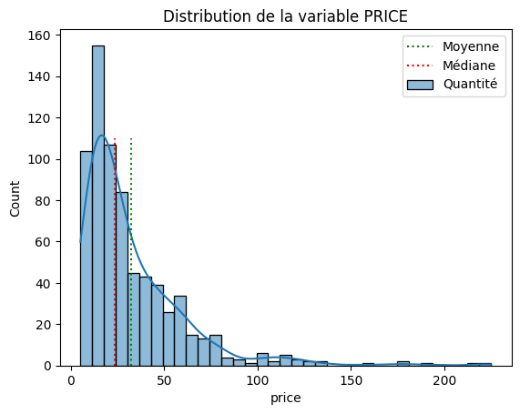

```python
ymax = 110

plt.title("Distribution de la variable PRICE")

sns.histplot(data=df_complete, x='price', kde=True, label="Quantité")
plt.vlines(x=mean,ymin=0, ymax = ymax , color="g", label="Moyenne", linestyles=":")
plt.vlines(x=med, ymin=0, ymax = ymax, color="r", label="Médiane", linestyles=":")

plt.legend()
```

I will use the quartiles due to the assymetrical distribution -> then the mean is far from the center ( mean != median != mode)  
If the line was in bell foam (Gaussian distribution), I should use the z-score due to symetrical distribution -> then mean perfectly at the middle ( mean == median == mod)

##### Visuel en boxplot (boite à moustache == quartiles visuels == Q1, Q2, Q3)

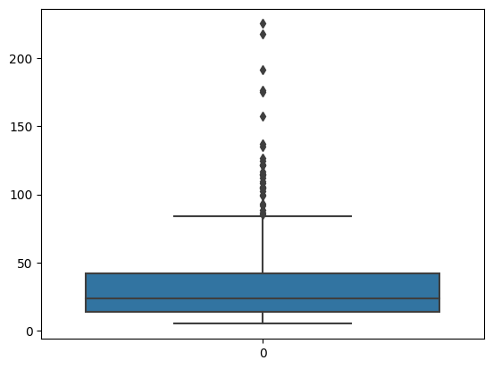

```python
sns.boxplot(data=df_complete.price)
```

```python
#Looking for 5 biggest outliers values
df_complete.sort_values("price", ascending=False).head(5)
```

|  | product_id | onsale_web | price | stock_quantity | stock_status | id_web | sku | total_sales | post_author | post_date | post_date_gmt | post_title | post_excerpt | post_name | post_modified | post_modified_gmt | guid | total_value_sales |
| --- | --- | --- | --- | --- | --- | --- | --- | --- | --- | --- | --- | --- | --- | --- | --- | --- | --- | --- |
| 199 | 4352 | 1 | 225.0 | 0 | outofstock | 15940 | 15940 | 5.0 | 2.0 | 2018-03-02 10:30:04 | 2018-03-02 09:30:04 | Champagne Egly-Ouriet Grand Cru Millésimé 2008 | Issu d’un assemblage de 70% de Pinot Noir du g... | champagne-egly-ouriet-grand-cru-millesime-2008 | 2020-03-07 11:18:45 | 2020-03-07 10:18:45 | https://www.bottle-neck.fr/?post_type=product&... | 1125.0 |
| 426 | 5001 | 1 | 217.5 | 20 | instock | 14581 | 14581 | 0.0 | 2.0 | 2018-07-17 09:45:39 | 2018-07-17 07:45:39 | David Duband Charmes-Chambertin Grand Cru 2014 | Robe cerise chatoyante. Un nez de fruits rouge... | david-duband-charmes-chambertin-grand-cru-2014 | 2020-05-16 09:00:05 | 2020-05-16 07:00:05 | https://www.bottle-neck.fr/?post_type=product&... | 0.0 |
| 587 | 5892 | 1 | 191.3 | 10 | instock | 14983 | 14983 | 3.0 | 2.0 | 2019-03-28 10:21:36 | 2019-03-28 09:21:36 | Coteaux Champenois Egly-Ouriet Ambonnay Rouge ... | Cet Ambonnay évoque les grands Pinots Noirs de... | coteaux-champenois-egly-ouriet-ambonnay-rouge-... | 2020-04-01 09:30:09 | 2020-04-01 07:30:09 | https://www.bottle-neck.fr/?post_type=product&... | 573.9 |
| 218 | 4402 | 1 | 176.0 | 8 | instock | 3510 | 3510 | 13.0 | 2.0 | 2018-03-22 11:21:05 | 2018-03-22 10:21:05 | Cognac Frapin VIP XO | La cuvée VIP XO à été enrichie d’eaux-de-vie t... | cognac-frapin-vip-xo | 2020-08-22 11:35:03 | 2020-08-22 09:35:03 | https://www.bottle-neck.fr/?post_type=product&... | 2288.0 |
| 553 | 5767 | 1 | 175.0 | 12 | instock | 15185 | 15185 | 0.0 | 2.0 | 2019-03-13 14:43:22 | 2019-03-13 13:43:22 | Camille Giroud Clos de Vougeot 2016 | Ce vin provient de vignes âgées de 50 ans situ... | camille-giroud-clos-de-vougeot-2016 | 2020-06-11 15:25:04 | 2020-06-11 13:25:04 | https://www.bottle-neck.fr/?post_type=product&... | 0.0 |

##### Utilisation de l'inter Quartile range

```python
# IQR Inter Quartile Range
Q1 = np.percentile(df_complete['price'], 25)

Q3 = np.percentile(df_complete['price'], 75)

IQR = Q3 - Q1

print("Old Shape: ", df_complete.shape)

#Highter than mustache
highter = np.where(df_complete['price'] >= (Q3 + 1.5 * IQR))
#Lower than mustache
lower = np.where(df_complete['price'] <= (Q1 - 1.5 * IQR))

#Archive outliers
df_outliers = df_complete.loc[(df_complete.index.isin(highter[0])) | df_complete.index.isin(lower[0])]

#Drop outliers
df_complete.drop(highter[0], inplace = True)
df_complete.drop(lower[0], inplace = True)

print("New Shape: ", df_complete.shape)
```

```
Old Shape:  (714, 18)
New Shape:  (682, 18)
```

```python
outliers = df_outliers["sku"].count()

outliers
```

```
32
```

```python
#Show outliers values
print("These are outliers: ", sorted(df_outliers["price"].tolist()))
```

```
These are outliers:  [85.6, 86.8, 88.4, 92.0, 93.0, 99.0, 100.0, 102.3, 104.0, 105.0, 105.0, 105.6, 108.5, 109.6, 112.0, 114.0, 115.0, 115.0, 116.4, 121.0, 121.0, 122.0, 124.8, 126.5, 135.0, 137.0, 157.0, 175.0, 176.0, 191.3, 217.5, 225.0]
```

##### Utilisation du z-score

```python
zvalue = np.abs(stats.zscore(df_complete['price']))
```

```python
threshold = 2

#Position of the outlier
outliers = np.where(zvalue > threshold)[0]

print(np.where(zvalue > threshold))

print(len(outliers))
```

```
(array([ 10,  18,  35,  66,  73, 125, 180, 194, 196, 197, 200, 213, 217,
       237, 248, 347, 410, 411, 412, 414, 427, 430, 474, 488, 498, 499,
       524, 586, 595, 596, 599, 614, 635, 640, 644, 679], dtype=int64),)
36
```

### Incoherences

- negative prices & negative stocks
- *id_web* have NaN -> rows deleted
- *id_web* differents foam (12345 | 1234-5 | boncadeau25)
- some columns with no-values: *["tax_class", "post_content", "post_password", "post_content_filtered"]* -> columns droped
- every rows in *webinfos* source are in double -> *["post_type"] == "product" are keep* and other copy in other dataframe
- some columns with no-values: *["virtual", "downloadable", "rating_count", "average_rating", "post_parent", "menu_order", "comment_count"]* -> columns droped
- some columns have no relevant informations *["post_status", "comment_status", "ping_status","tax_status", "post_type", "post_mime_type"]* -> columns droped and copy in other dataframe
- some infos with html tags in *df_webinfos["post_excerpt"]* -> tags deleted with fonction created